# Introduction to R

2018-12-13

## Why learning R?

R is a language and environment for **statistical** computing and **graphics**.

### Advantages of R

- free software (unlike Matlab)
- easy to download/install/update
- easy to process big files and analyse huge amounts of data
- integrated data visualisation tools
- programs can be integrated with the text to produce fully reproducible manuscripts
- most relevant statistical environment for data analysis in the life sciences

More details on https://www.r-project.org/about.html

### Learning objectives

[figure not shown]

- Apply your knowledge from Introduction to Bioinformatics in a new environment
- Learn Base R
- Structure your research data (*tidy data*)
- Learn about *literate programming* using RMarkdown to produce reproducible research
- Get to know a set of packages for easy data manipulation and visualisation (*tidyverse* including *dplyr* and *ggplot*)
- Practice R in a learning environment and with first projects
- Eventually, write your project report in RMarkdown

## Set up for R

### R lecture

- R1 Intro
- R2 Tidy data (Tue morning)
- R3 Getting data into R (Tue afternoon)
- R4 Data manipulation (Wed afternoon)
- R5 Visualisation (Thu afternoon)
- R6 Genomics in R (Fri morning)

## How to install R on my PC?

R is already installed on your computers, this is for reference.

### R

- go to http://cran.r-project.org
- choose your system
- choose **base**
- download R
- run the downloaded file

### Rstudio

- go to https://www.rstudio.com/
- choose the **free RStudio Desktop** version
- choose your system
- download
- run the downloaded file

## RStudio

[figure not shown]

## Rstudio

### What is it?

### IDE

[RStudio](https://www.rstudio.com/products/RStudio/) is an Integrated Development Environment. It makes working with R much easier.

### Warning

Don’t mix up **R** and **RStudio**.  
**R** needs to be installed first.

### Features

- *Console* to run **R**, with syntax highlighter
- *Editor* to work with scripts
- *Viewer* for data / plots / website
- *Package management* (including building)
- *Autocompletion* using `TAB`
- [*Cheatsheets*](https://www.rstudio.com/resources/cheatsheets/)
- *Git* integration for versioning
- *Inline* outputs
- *Keyboard shortcuts*

## Rstudio

### The 4 panels layout

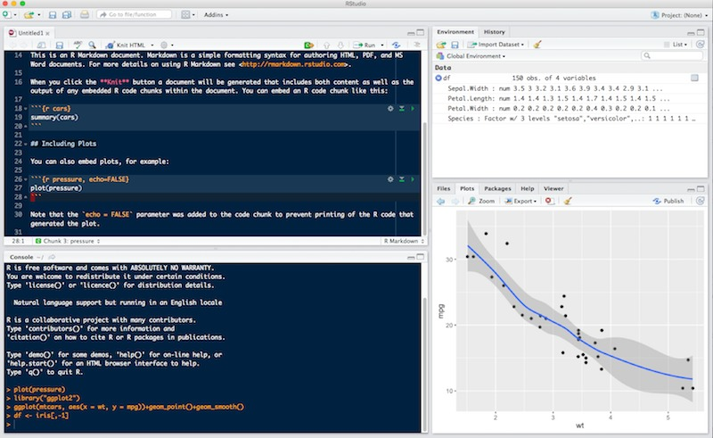

## Four panels

### Scripting

- Represents the main window
- Using a **Rmarkdown** document is highly recommended
- Tabs to switch documents

### Environment

- Environment: shows loaded objects and their `str()`
- History
- nice `git` integration
- database **connections** interface

### Console

- Can be hidden when using **inline** outputs
- `rmarkdown` output logs
- An optional `terminal` tab

### Files / Plots / Help

- package management tab
- Plots panel might be unecessary when using **inline** outputs
- useful help tab

## Getting started

### Use **R** and **RStudio**

Do the following:

- Open up RStudio
- Maximise the RStudio window
- Click the Console pane, at the prompt (`>`) type in `3 + 2` and hit enter

```r
> 3 + 2
```

## Arithmetic operations

- `+`: addition
- `-`: subtraction
- `*`: multiplication
- `/`: division
- `^` or `**`: exponentiation
- `%%`: modulo (remainder after division)
- `%/%`: integer division

### **Remember** that R will:

- first perform **exponentiation**
- then multiplications and/or divisions
- and finally additions and/or subtractions.

If you need to change the priority during the evaluation, use parentheses – *i.e.* `(` and `)` – to group calculations.

## Data types in R

### Four main types

| Type | Example |
| --- | --- |
| numeric | integer (2), double (2.34) |
| character (strings) | “Hello !” |
| boolean | TRUE / FALSE |
| complex | 2+0i |

### Special types

```r
NA   # not available, missing data
NA_real_
NA_integer_
NA_character_
NA_complex_
NULL # empty
-Inf/Inf # infinite values
NaN # Not a Number
```

Call the command **`class()`** or **`typeof()`** to see what data you are working with.

## Numeric variables

### Integers

Integers are stored 32-bit long registers and limited to a little more than 2 billion.

```r
.Machine$integer.max
```

```
[1] 2147483647
```

### Double

Doubles can be bigger because they are stored as **double precision floating point numbers**, which have two pieces:

- the exponent (like 308 below)
- the “significant” (like 1.797693 below).

```r
.Machine$double.xmax
```

```
[1] 1.797693e+308
```

```r
# Clear some variables to clean the env for ls() demo
rm(double_precision)
```

In practice, numeric computations always produce `double` results thus the name `numeric` is used as a synonym.

## Numeric variables

R will automatically convert (coerce) between the numeric classes when needed.

### `double` is the default

- Most math is done using double precision
- Thus it is the default storage.

```r
is.numeric(1)
```

```
[1] TRUE
```

```r
is.integer(1)
```

```
[1] FALSE
```

### `integer` must be forced

Sometimes you may want to specifically store a vector as integers:

- if you know that they will never be converted to doubles (used as ID values or indexing)
- since integers require less storage space.

```r
is.numeric(1L)
```

```
[1] TRUE
```

```r
is.integer(1L) #Putting capital 'L' after an integer forces it to be stored as an integer.
```

```
[1] TRUE
```

## Structures

### Vectors

- elements of the same type are organised as vectors
- a single number is already a vector
- `c()` is the function to **concatenate** elements

### Atomic vectors

Each **atomic** vector contains only a single type of data

- The type of each atom is the same
- The size of each atom is 1 (single element)

### Example

```r
# Logical
c(TRUE, FALSE, TRUE)
```

```
[1]  TRUE FALSE  TRUE
```

```r
# double
c(1, 5, 7)
```

```
[1] 1 5 7
```

```r
# character
c("character", "sequence")
```

```
[1] "character" "sequence"
```

```r
4
```

```
[1] 4
```

```r
is.vector(4)
```

```
[1] TRUE
```

```r
identical(4, c(4))
```

```
[1] TRUE
```

## Variables in R

### Assignment

In R you create **`objects`** by a process called **assignment**.

### Example of assignment

```r
x <- 7
```

### Create a new variable based on **v1**

```r
v1 <- 2
v2 <- (v1^5 - v1)
v2
```

```
[1] 30
```

### Warning

Here is another way to do an assignment in R:

```r
x = 7
```

This **SHOULD NOT** be read as “x equals 7”, which will result in confusion later.  
Using `<-` instead of `=` is encouraged.

## Naming of variables

> **The World’s Worst Variable Name** to be: data  
> Of course it’s data! That’s what variables contain! That’s all they ever can contain. It’s like you’re packing up your belongings to move to a new house, and on the side of the box you write, in big black marker, “things”. [Andy Lester](http://archive.oreilly.com/pub/post/the_worlds_two_worst_variable.html)

### Use meaningful names

- **matrix_multiplication** is better than **mult**
- Do not fear long variable names!

### Stay consistent: use a [naming convention](https://journal.r-project.org/archive/2012-2/RJournal_2012-2_Baaaath.pdf)

- alllowercase
- period.separated
- **underscore_separated** (*recommended by [Hadley Wickham](http://adv-r.had.co.nz/Style.html)*)
- lowerCamelCase
- UpperCamelCase

### Use specific names

```r
total <- price * qty
total2 <- total - discount
total2 <- total2 + total * taxrate
total3 <- purchase_order_value + available_credit

if ( total2 < total3 ) {
    print "You can't afford this order.";
}
```

If you’re faced with naming something total2, change the existing name to something more specific.

## Workspace

### Check variable content

There are several ways to check content of variable:

- Select the variable and press Ctrl+Enter (cmd + Enter for Mac)
- run command

  ```r
  print(x)
  ```

  ```
  [1] 7
  ```

- In R Console type **x** to see it’s value.

### Listing variables

- To get a list of all of the variables that have been defined use the `ls()` command:

  ```r
  ls()
  ```

  ```
  [1] "old_col"      "swirl_mailto"
  [3] "v1"           "v2"
  [5] "x"
  ```

- Check “Environment” tab in RStudio

## Practice time!

### Using `swirl`

Type in R console:

```r
library(swirl)
#install_course("R Programming E")
swirl()

#Lesson 1, 2, 3
```

- Choose the “R Programming E” course.
- Complete lessons **1, 2** and **3**.
- In the end of the lesson send the email to eric.koncina@uni.lu  
  The email subject should be generated automaticly by swirl, in the email body place your last command used in the lesson.

## Operations on vectors

### Create a vector in R

- Create a vector with several elements using `c()`

```r
a <- c(1, 2, 3)
a
```

```
[1] 1 2 3
```

```r
a <- c(1:3)
a
```

```
[1] 1 2 3
```

```r
a + 5
```

```
[1] 6 7 8
```

### Basic R operations

```r
a * 4
```

```
[1]  4  8 12
```

```r
sqrt(a)
```

```
[1] 1.000000 1.414214 1.732051
```

```r
exp(a)
```

```
[1]  2.718282  7.389056 20.085537
```

```r
log(a)
```

```
[1] 0.0000000 0.6931472 1.0986123
```

### Warning

- R is vectorised which is a very powerful feature.
- If two vectors of different length are used, *R* recycles the smallest one:

```r
a <- c(1, 2, 3, 4, 5, 6)
b <- c(10, 11, 12)
a + b
```

```
[1] 11 13 15 14 16 18
```

## Operations with vectors

- `log()`, `exp()`, `sin()`, `cos()`, `tan()`, `sqrt()`, …
- `max()` and `min()`
- `range()`
- `sum(x)` sums all elements of `x`
- `mean(x)` computes the mean (`sum(x) / length(x)`)
- `var(x)` is the variance (`sum((x - mean(x))^2) / (length(x) - 1)`)
- use `sort()` to arrange elements in increasing order (or `order()` to get the sorted indices and make more complex sorting).

## Operations with vectors

### Mini-task

How would you arrange your vector in a decreasing order using `sort()`?

### Help

- **`help()`** returns a full description of the query command: what it does, what it needs as input, what will be produced in output
- Use the help tab in the lower right Rstudio panel

```r
help(sort)
?sort
```

### Solution

```r
sort(a, decreasing = FALSE)
```

```
[1] 1 2 3 4 5 6
```

```r
sort(a, decreasing = TRUE)
```

```
[1] 6 5 4 3 2 1
```

## Functions to Provide Information about Vectors

- `length()` to get the number of elements in a vector
- `class()` returns the type of an object
- `is.logical()`, `is.numeric()`, `is.character()`, `is.integer()` to test for the type of an object
- `is.null()` to test whether an object is empty (*i.e.* has no content).
- `is.na()` to test if the value is not available

  ```r
  is.na(c(3, 1, NA))
  ```

  ```
  [1] FALSE FALSE  TRUE
  ```

- `as.numeric()`, `as.character()`, `as.logical()`, … to coerce objects from one type to another

## Logical Operators

- The usual arithmetic operators return logicals `>`, `<`, `>=`, `<=`, `==` and `!=`
- Are also vectorised (are working element-wise on two inputs)
- Output is a **logical vector**.
- Combine conditions using `&` (AND) and `|` (OR).
- `any()` returns `TRUE` if any value is TRUE
- `all()` returns `TRUE` if all values are TRUE

### Warning

- `&` and `|` are performing elementwise
- `&&` and `||` are only comparing the first element of each vector

```r
c(FALSE, TRUE, TRUE) & c(TRUE, TRUE, FALSE)
```

```
[1] FALSE  TRUE FALSE
```

```r
c(FALSE, TRUE, TRUE) && c(TRUE, TRUE, FALSE)
```

```
[1] FALSE
```

## Logical

### Logical binary

Two possible values represented by `TRUE` and `FALSE`.

```r
a <- c(3, 7, 1, 2, 4)
a > 2
```

```
[1]  TRUE  TRUE FALSE FALSE  TRUE
```

```r
a == 2
```

```
[1] FALSE FALSE FALSE  TRUE FALSE
```

```r
!(a <= 3)
```

```
[1] FALSE  TRUE FALSE FALSE  TRUE
```

### Find which element is…

```r
a
```

```
[1] 3 7 1 2 4
```

```r
which(a > 2)
```

```
[1] 1 2 5
```

```r
a[which(a > 2)]
```

```
[1] 3 7 4
```

## Practice time!

Type in R console:

```r
swirl()
#Lesson 4, 8
```

Choose the “R Programming E” course. Complete lessons **4** and **8**. In the end of the lesson send the email to eric.koncina@uni.lu

The email subject should be generated automaticly by swirl, in the email body place your last command used in the lesson.

## Subsetting Vectors

### Build in vectors

- R has a few built in vectors.
- One of these is **LETTERS**.

```r
LETTERS
```

```
 [1] "A" "B" "C" "D" "E" "F" "G" "H" "I" "J" "K" "L" "M" "N"
[15] "O" "P" "Q" "R" "S" "T" "U" "V" "W" "X" "Y" "Z"
```

To extract the first element from `LETTERS` (the letter A), use square brackets:

```r
LETTERS[1]
```

```
[1] "A"
```

## Your turn!

### How to get following outputs?

```
[1] "B" "C" "D" "E"
```

```
[1] "B" "C" "D" "E" "G"
```

```
[1] "A" "B" "C" "D" "E" "Y"
```

### Solution

```r
LETTERS[2:5]
```

```
[1] "B" "C" "D" "E"
```

```r
LETTERS[c(2:5, 7)]
```

```
[1] "B" "C" "D" "E" "G"
```

```r
LETTERS[c(1:5, length(LETTERS) - 1)]
```

```
[1] "A" "B" "C" "D" "E" "Y"
```

## Named vectors

### Example

```r
v <- c("Mary", "Sue")
names(v) <- c("First", "Last")
v
```

```
 First   Last
"Mary"  "Sue"
```

```r
v <- c(First = "Mary", Last = "Sue")
v
```

```
 First   Last
"Mary"  "Sue"
```

### Retrieve elements by names

### retrieve the first member by its name

```r
v["First"]
```

```
 First
"Mary"
```

### reverse the order with a character string index vector

```r
v[c("Last", "First")]
```

```
  Last  First
 "Sue" "Mary"
```

## Practice time!

Type in R console:

```r
swirl()
#Lesson 5, 6
```

Choose the “R Programming E” course. Complete lessons **5** and **6**. In the end of the lesson send the email to eric.koncina@uni.lu

The email subject should be generated automaticly by swirl, in the email body place your last command used in the lesson.

## Structures

### Factors

- The function `factor()` converts strings to factors
- `levels` is the dictionary

```r
fac <- factor(c("AA", "BB", "AA", "CC"))
fac
```

```
[1] AA BB AA CC
Levels: AA BB CC
```

```r
str(fac)
```

```
 Factor w/ 3 levels "AA","BB","CC": 1 2 1 3
```

```r
is.vector(fac)
```

```
[1] FALSE
```

## Factors

- A factor-type vector contains a set of numeric codes with character-valued levels.
- Example: A family of two girls (1) and four boys (0):

  ```r
  kids <- factor(c(1, 0, 1, 0, 0, 0),
                 levels = c(0, 1),
                 labels = c("boy", "girl"))
  kids
  ```

  ```
  [1] girl boy  girl boy  boy  boy
  Levels: boy girl
  ```

  ```r
  class(kids)
  ```

  ```
  [1] "factor"
  ```

  ```r
  typeof(kids)
  ```

  ```
  [1] "integer"
  ```

### Remark

- Required for (some) statistical analysis
- When manipulating the data, factors are a total pain
- Factor levels remain around even if you remove all examples of a particular level.
- It is a good practice to introduce factors at the very end of your analysis pipeline once required.

### Example

```r
levels(kids)
```

```
[1] "boy"  "girl"
```

```r
kids <- kids[kids != "boy"]
levels(kids) # still the same levels
```

```
[1] "boy"  "girl"
```

```r
table(kids) # even though one level has 0 entries!
```

```
kids
 boy girl
   0    2
```